# covariant & contravariant & Metric Tensor

### **NOTES ON STATISTICS, PROBABILITY and MATHEMATICS**

### Covariant, Contravariant & the Metric Tensor:

#### Biorthogonal system in $\mathbb R^n$:

Given the matrix of dot products between basis vectors

$$A = \begin{bmatrix}\mathbf e_1 \cdot
\mathbf e_1 & \mathbf e_1 \cdot \mathbf e_2 \\
\mathbf e_2 \cdot \mathbf e_1 & \mathbf e_2 \cdot \mathbf
e_2\end{bmatrix}$$

the [biorthoganility system](https://en.wikipedia.org/wiki/Dual_basis) in $\mathbb R^n$:

$$\mathbf e^k \cdot \mathbf e_s =
\delta^k_s = \sum_{q=1}^n e^{kq}e_{qs}= \begin{bmatrix}\mathbf e^1 \cdot
\mathbf e^1 & \mathbf e^1 \cdot \mathbf e^2 \\
\mathbf e^2 \cdot \mathbf e^1 & \mathbf e^2 \cdot \mathbf
e^2\end{bmatrix}\begin{bmatrix}\mathbf e_1 \cdot \mathbf e_1 &
\mathbf e_1 \cdot \mathbf e_2 \\
\mathbf e_2 \cdot \mathbf e_1 & \mathbf e_2 \cdot \mathbf
e_2\end{bmatrix}$$

the values of $e^{kq}$ correspond to the entries of the inverse matrix of $A.$ So that

$$\mathbf e^k = \sum_{q=1}^n e^{kq}
\mathbf e_q$$

Example:

If the basis vectors are $\mathbf e_1 = [1,0.8]^\top$ and $\mathbf e_2 = [-0.25,1]^\top$, the matrix of dot products is

$$A = \begin{bmatrix}\mathbf e_1 \cdot
\mathbf e_1 & \mathbf e_1 \cdot \mathbf e_2 \\
\mathbf e_2 \cdot \mathbf e_1 & \mathbf e_2 \cdot \mathbf
e_2\end{bmatrix} =\begin{bmatrix} 1.64 & 0.55 \\ 0.55 & 1.06
\end{bmatrix}$$

with

$$A^{-1} = \begin{bmatrix}\mathbf e^1
\cdot \mathbf e^1 & \mathbf e^1 \cdot \mathbf e^2 \\
\mathbf e^2 \cdot \mathbf e^1 & \mathbf e^2 \cdot \mathbf
e^2\end{bmatrix} =\begin{bmatrix} 0.74 & -0.38 \\ -0.38 & 1.14
\end{bmatrix}$$

and

$$\mathbf e^1 = 0.74 \mathbf e_1 -0.38
\mathbf e_2$$

while

$$\mathbf e^2 = -0.38 \mathbf e_1 + 1.14
\mathbf e_2$$

This is reflected on the image below (to the left), in which the cobasis vectors are portrayed as arrow vectors, as well as a stack. Notice how a vector $[3,2]^\top = 3 \mathbf e_1 + 2 \mathbf e_2$ can be decomposed into its components in the basis vectors by projecting the actual vector onto the cobasis vectors as it would a flash light perpendicular to the cobasis vectors (“A Student’s Guide to Vectors and Tensors” by Daniel A. Fleisch):

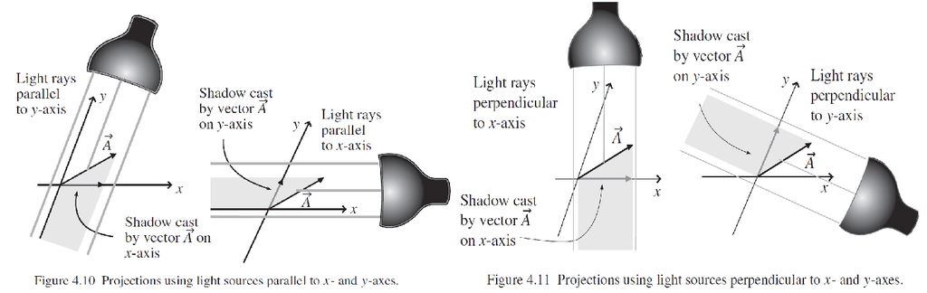

Notice how the cobasis vector change opposite to the basis vectors under a change of coordinates, and the density of the stacks decreases when the cobasis vectors decrease in size (more spaced out). On the right image below, the vector $[3,2]^\top = 3 \mathbf e_1 + 2 \mathbf e_2$ is not an invariant, increasing in size with the basis vectors. The point of the image is to depict the decrease in the cobasis vectors and natural spacing out of the stack of covectors, each line in them corresponding to a set line of the linear functional

$$[e^1 , e^2]\begin{bmatrix} x \\
y\end{bmatrix} = \text{constant}$$

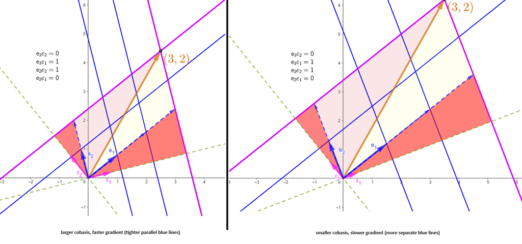

In the following illustration the vector is invariant, and the basis vectors $(\mathbf e_1, \mathbf e_2)$ keep on increasing in size. To maintain the biorthogonality condition, the dual basis vectors $(\mathbf \varepsilon_1, \mathbf \varepsilon_2)$ are initially large, corresponding to steep gradient (highly packed stacks). Notice how the idea of a lamp perpendicular to the dual basis vectors is illustrated in the video.

The changing coordinates of the vector can be retrieved by checking the number of stacks under the shadow of the vector.

**The steeper the gradient (the larger the covector basis, or equivalently, the more tightly packed the stacks are) the larger the values of the components, i.e. they are covariant. On the other hand, the larger the contravariant vectors, the smaller the values of the components.**

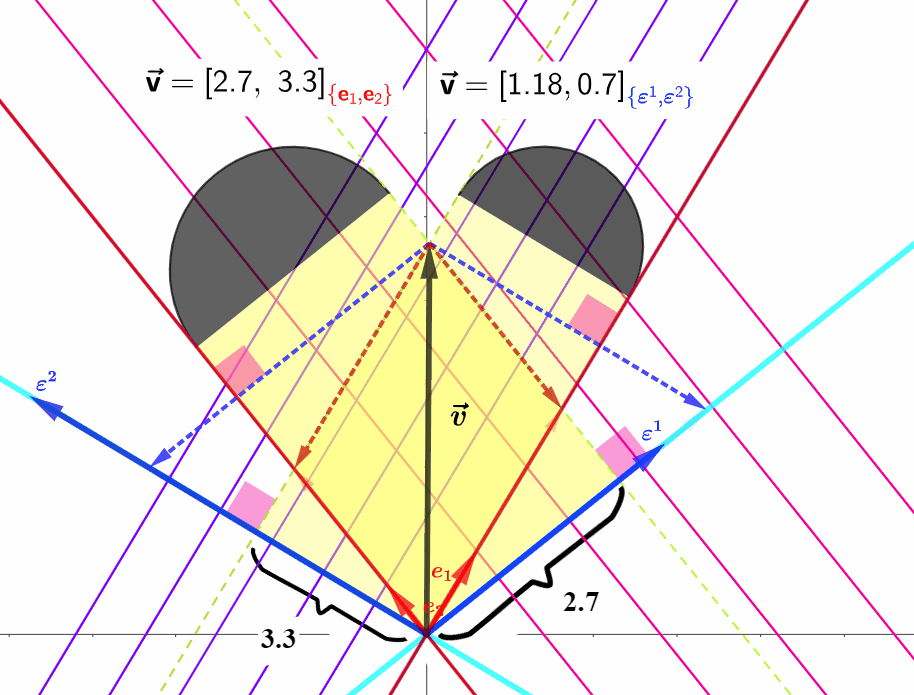

See also [this post](https://physics.stackexchange.com/a/821513/150551) around the animated graphic above:

Given the [metric tensor for the basis vectors](https://cloud.githubusercontent.com/assets/9312897/18643188/fa8b6c8a-7e71-11e6-99dd-969f835b03ce.png)

$$A = \begin{bmatrix}\mathbf e_1 \cdot
\mathbf e_1 & \mathbf e_1 \cdot \mathbf e_2 \\
\mathbf e_2 \cdot \mathbf e_1 & \mathbf e_2 \cdot \mathbf
e_2\end{bmatrix}$$

the [biorthoganility system](https://en.wikipedia.org/wiki/Dual_basis) in $\mathbb R^n$:

$$\mathbf e^k \cdot \mathbf e_s =
\delta^k_s = \sum_{q=1}^n e^{kq}e_{qs}= \begin{bmatrix}\mathbf e^1 \cdot
\mathbf e^1 & \mathbf e^1 \cdot \mathbf e^2 \\
\mathbf e^2 \cdot \mathbf e^1 & \mathbf e^2 \cdot \mathbf
e^2\end{bmatrix}\begin{bmatrix}\mathbf e_1 \cdot \mathbf e_1 &
\mathbf e_1 \cdot \mathbf e_2 \\
\mathbf e_2 \cdot \mathbf e_1 & \mathbf e_2 \cdot \mathbf
e_2\end{bmatrix}$$

the values of $e^{kq}$ correspond to the entries of the inverse matrix of $A.$ So that

$$\mathbf e^k = \sum_{q=1}^n e^{kq}
\mathbf e_q$$

In animated graphical representation below the vector $\vec v = \left [2.7, 3.3 \right]^\top$ is kept invariant. These components are in the initial basis vectors $e_1 = \left [0.3, 0.5 \right ]^\top$ and $e_1 = \left [-0.24, 0.3 \right ]^\top$. The basis vectors $(e_1, e_2)$ are transformed simply by progressively stretching them, leading to decreasing coordinate components (contravariant transformation).

The dual basis vectors are calculated from the inverse of the metric tensor matrix:

$$A = \begin{bmatrix}
0.34 & 0.08 \\ 0.08 & 0.15
\end{bmatrix} \implies
A^{-1} = \begin{bmatrix}
3.35 & -1.77 \\ -1.77 & 7.71
\end{bmatrix}$$

resulting in

$$\begin{align}
\varepsilon^1 &= 3.35 \mathbf e_1 -1.77 \mathbf
e_2=[1.43,1.14]^\top\\
\varepsilon^2 &= -1.77 \mathbf e_1 +7.71 \mathbf e_2= [-2.38,
1.43]^\top
\end{align}$$

To maintain the biorthogonality condition, the dual basis vectors $(\mathbf{\varepsilon}^1, \mathbf{\varepsilon}^2)$ are initially long (drawn as arrow vectors}, corresponding to a steep gradient or tightly packed stacks or level sets:

$$[e^1 , e^2]\begin{bmatrix} x \\
y\end{bmatrix}=e^1x + e^2y = \text{constant }n \in \mathbb Z \implies
\begin{cases}
y = \frac{n - 1.43x}{1.14}\color{magenta}{\bf\text{ \\\\}} \\
y = \frac{n + 2.38x}{1.43} \color{purple}{\bf\text{ //}}
\end{cases}$$

The covariant components can be calculated from counter-variant components using the metric $A \vec v.$

The changing components of the vector under the initial basis can be retrieved by checking the number of stacks are comprised under the shadow of the vector, which is the idea behind forms as oriented projections.

The steeper the gradient (the larger the covector basis, or equivalently, the more tightly packed the stacks are) the larger the values of the components. This makes perfect sense because we are reading out the values of the components in the original basis, which start off small, and hence, they will have larger components. The larger the vector basis of the dual space, the more packed the level sets or stacks, consistent with the covariant nature of the dual space.

Notice how the initial components can be directly read by counting the number of magenta and purple lines projecting inside the dashed green lines (shadow of the original vector), crossing the cyan lines.

The dashed red and blue arrows demonstrate the mutual orthogonality of the components in the contravariant and covariant bases: in the contravariant (parallel to axes) original basis, the construction (in red) is orthogonal to the cobasis vectors; in the covariant basis (perpendicular to axes) construct, the lines (in blue) are orthogonal to the lines spanned by the original basis vectors.

#### Change to oblique coordinates:

From [this introductory differential geometry series online](https://youtu.be/AKPZkHvqTao?list=PLD1448E024E04C24D) ushering in the concepts of **contravariant** ($A^i$) and **covariant** ($A_i$) of a vector as a change of coordinates:

In the setting of oblique coordinates, the $y$ axis is tilted, but the $x$ axis stays unchanged:

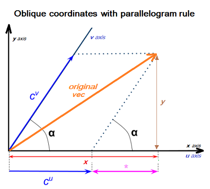

The **contravariant** is calculated as:

$\tan(\alpha) =\large \frac{y}{*}$; and therefore, $\large * = \frac{y}{\tan(\alpha)}$

and

$$\begin{align}c^u &= x - *
\\[3ex]&= x - \frac{y}{\tan(\alpha)}\end{align}$$

while

$$c^v =
\frac{y}{\sin(\alpha)}$$

Therefore the original orthogonal coordinates will transform into the new oblique coordinates through the matrix

$$H = \begin{bmatrix} 1 & -
\frac{1}{\text{tan}(\alpha)} \\
0 & \frac{1}{\text{sin}(\alpha)}
\end{bmatrix}$$

as follows:

$$\begin{bmatrix} 1 & -
\frac{1}{\text{tan}(\alpha)} \\
0 & \frac{1}{\text{sin}(\alpha)}
\end{bmatrix}
\begin{bmatrix} x \\ y
\end{bmatrix}=
\begin{bmatrix} c^u \\ c^v
\end{bmatrix} = \begin{bmatrix} c^1 \\ c^2
\end{bmatrix}$$

On the other hand, the **covariant** is calculated as:

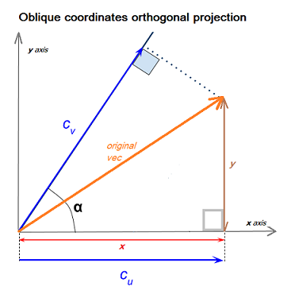

where,

$$c_u = x$$
and

$$c_v = x\,\cos(\alpha) + y\,
\sin(\alpha)\tag 1$$

This expression (1) is derived as follows:

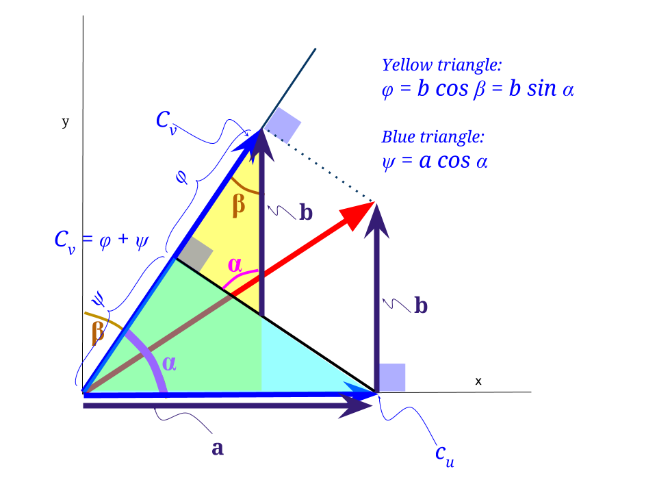

The angles $\alpha$ and $\beta$ are complementary, and $\sin \alpha = \cos \beta$.

$\varphi= b \cos \beta = b \sin \alpha$

$\psi = a \cos \alpha$

$c_v = \psi + \varphi = a \cos \alpha + b \sin \alpha$

It follows that the covariant transformation will be through the matrix

$$M = \begin{bmatrix} 1 & 0 \\ \cos
\alpha & \sin \alpha \end{bmatrix}$$

Therefore,

$$\begin{bmatrix} 1 & 0 \\
\cos\alpha & \sin \alpha
\end{bmatrix}
\begin{bmatrix} x \\ y
\end{bmatrix}=
\begin{bmatrix} c_u \\ c_v
\end{bmatrix} = \begin{bmatrix} c_1 \\ c_2
\end{bmatrix}$$

From [this video](https://youtu.be/qDLmJE2bOy4),

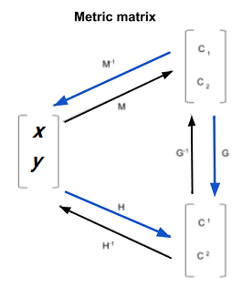

$G$ is the **METRIC TENSOR**, and turns the covariate into the contravariate:

[See this post for metric tensor](http://www.mathpages.com/rr/s5-02/5-02.htm), and [this other one](http://web.mit.edu/edbert/GR/gr1.pdf).

From [this presentation](https://youtu.be/C76lWSOTqnc):

To preserve the length of a vector $\vec v$ regardless of the whether referenced to coordinates with orthonormal basis vectors $\{\vec e_1,\vec e_2\},$ or the alternative oblique coordinates $\{\vec{ \tilde e_1}, \vec {\tilde e_2}\}$ we need to calculate norm as the dot product.

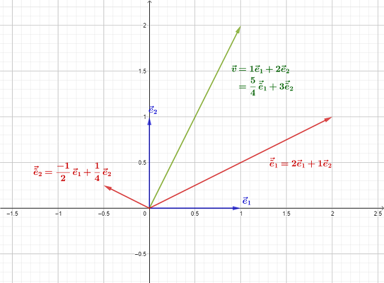

With respect to the orthonormal basis vectors,

The last line is consequence of the orthogonality of the basis vectors. However, when using non-orthogonal coordinates we’ll need to calculate the dot products of the basis vectors. Paralleling equation (1):

$$\begin{align}\Vert \vec v
\Vert^2&=(\tilde v^1)^2 \left(\vec{\tilde e_1}\cdot \vec{\tilde
e_1}\right)+ 2 \tilde v^1 \tilde v^2 \left(\vec{\tilde e_1}\cdot
\vec{\tilde e_2}\right)+(\tilde v^2)^2\left(\vec{\tilde e_2
}\cdot\vec{\tilde e_2}\right)\end{align}\tag 2$$

Calculating the dot products, then,

$$\begin{align}
\vec{\tilde e_1}\cdot \vec{\tilde e_1}&= (2\vec e_1+1\vec e_2)\cdot
(2\vec e_1 + 1\vec e_2)\\[2ex]
&=4 \vec e_1 \cdot \vec e_1 + 2\cdot 2 \vec e_1 \vec e_2 + 1 \vec
e_2\vec e_2\\[2ex]
&= 4 + 1 \\[2ex]
&=5
\end{align}$$
$$\begin{align}
\vec{\tilde e_2}\cdot \vec{\tilde e_2}&= \left(-\frac{1}{2}\vec
e_1+\frac{1}{4}\vec e_2\right)\cdot \left(-\frac{1}{2}\vec
e_1+\frac{1}{4}\vec e_2\right)\\[2ex]
&=\frac{1}{4} \vec e_1 \cdot \vec e_1 - 2\cdot \frac{1}{8} \vec e_1
\vec e_2 + \frac{1}{16} \vec e_2\vec e_2\\[2ex]
&= \frac{1}{4} + \frac{1}{16} \\[2ex]
&=\frac{5}{16}
\end{align}$$

$$\begin{align}
\vec{\tilde e_1}\cdot \vec{\tilde e_2}&= (2\vec e_1+1\vec e_2)\cdot
\left(-\frac{1}{2}\vec e_1+\frac{1}{4}\vec e_2\right)\\[2ex]
&=-1 \vec e_1 \cdot \vec e_1 + 2\cdot \frac{1}{2} \vec e_1 \vec e_2
+ \frac{1}{4} \vec e_2\vec e_2\\[2ex]
&= -1 + \frac{1}{4} \\[2ex]
&=-\frac{3}{4}
\end{align}$$

Plugging these results in equation (2):

$$\begin{align}\Vert \vec v
\Vert^2&=(\tilde v^1)^2 5+ 2 \tilde v^1 \tilde v^2
\left(-\frac{3}{4}\right)+(\tilde
v^2)^2\left(\frac{5}{16}\right)\end{align}$$
Now, in the graph above we have as given that $\vec v = \frac{5}{4} \vec {\tilde e_1} + 3 \vec{\tilde e_2}.$ Therefore,

$$\begin{align}\Vert \vec v
\Vert^2&=\left(\frac{5}{4}\right)^2 \left(5\right)+ 2
\left(\frac{5}{4}3\right)
\left(-\frac{3}{4}\right)+\left(3\right)^2\left(\frac{5}{16}\right)=5\end{align}$$

This can be expressed as

$$\begin{bmatrix}\tilde v^1 & \tilde
v^2\end{bmatrix}\;\color{blue}{\begin{bmatrix}5 &
-\frac{3}{4}\\-\frac{3}{4}&
\frac{5}{16}\end{bmatrix}}\;\begin{bmatrix}\tilde v^1 \\ \tilde
v^2\end{bmatrix}=\begin{bmatrix}\frac{5}{4} &
3\end{bmatrix}\;\color{blue}{\begin{bmatrix}5 &
-\frac{3}{4}\\-\frac{3}{4}&
\frac{5}{16}\end{bmatrix}}\;\begin{bmatrix}\frac{5}{4} \\
3\end{bmatrix}$$

The metric tensor is

$$g_{\vec{\tilde
e_i}}=\color{blue}{\begin{bmatrix}5 &
-\frac{3}{4}\\-\frac{3}{4}& \frac{5}{16}\end{bmatrix}}_{\vec{\tilde
e_i}}$$

In the case of the orthogonal matrix, the metric tensor is

$$g_{\vec{
e_i}}=\color{blue}{\begin{bmatrix}1 & 0\\0&
1\end{bmatrix}}_{\vec{ e_i}}$$

So the metric tensor is the matrix of dot products, such in the case of

$$g_{\vec{\tilde
e_i}}=\color{blue}{\begin{bmatrix}\vec{\tilde e_1}\cdot \vec{\tilde
e_1}& \vec{\tilde e_1}\cdot \vec{\tilde e_2}\\\vec{\tilde e_2}\cdot
\vec{\tilde e_1}& \vec{\tilde e_2}\cdot \vec{\tilde
e_2}\end{bmatrix}}_{\vec{\tilde e_i}}$$

In Einstein’s notation

$$\Vert \vec v\Vert^2=\tilde v^i\tilde
v^j\left(\vec{\tilde e_i\cdot \tilde e_j}\right)=\tilde v^i\tilde
v^j\,\color{blue}{g_{ij}}.$$
The metric tensor is a $(0,2)$-tensor, and it does eat two vectors (e.g. $\vec v$ and $\vec v$ in $\Vert \vec v \Vert$) to produce a scalar number.

#### [GEOMETRIC INTERPRETATION OF CURVILINEAR COORDINATES AND THE METRIC TENSOR:](https://youtu.be/NJzzbGcIYX0)

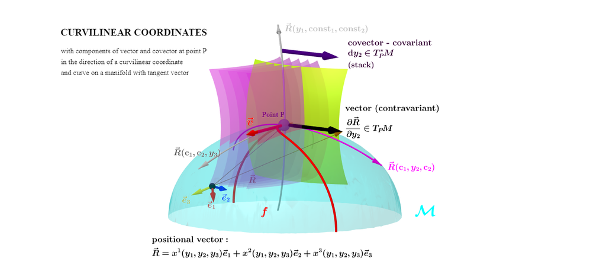

The position vector $\vec r$ of a point in the manifold $\mathcal M$ is given as functions of the basis vectors $\vec e_i,$ i.e. $\vec r(y^1,y^2,y^3)=x^1(y^1,y^2,y^3)\vec e_1 + x^2(y^1,y^2,y^3)\vec e_2 + x^3(y^1,y^2,y^3)\vec e_3.$

The new **coordinate curves or axes** are generated by allowing only one of the $\vec y_i$ coordinates to vary, while holding the other two constant, i.e. $\left (\vec r(y^1,c_2,c_3),\vec r(c_1,y^2,c_3),\vec r(c_1,c_2,y^3) \right ).$ The derivative of the position vector along each of the coordinate curves (one of them highlighted in black on the diagram) is responsible for the **contravariant** basis vectors $\left\{\frac{\partial \vec r}{\partial y^1}, \frac{\partial \vec r}{\partial y^2}, \frac{\partial \vec r}{\partial y^3} \right \}.$

The covariant vectors are best represented by a stack (akin to a contour plot), and represent the gradient along each of the coordinates - the gradient will be realized as soon as a smooth function is provided. Notice that all of this construct happens at a particular point.

When a function $f$ is provided, the tangent vector $\vec v$ (in red) at point $P$ happens to “pierce” approximately $1.5$ layers of the covector denoting the gradient in the direction of $y_2.$ This makes sense in the diagram, because of the bend in the curve is progressing nearly perpendicular to the vector $\frac{\partial \vec R}{\partial y_2}$ around point $P.$

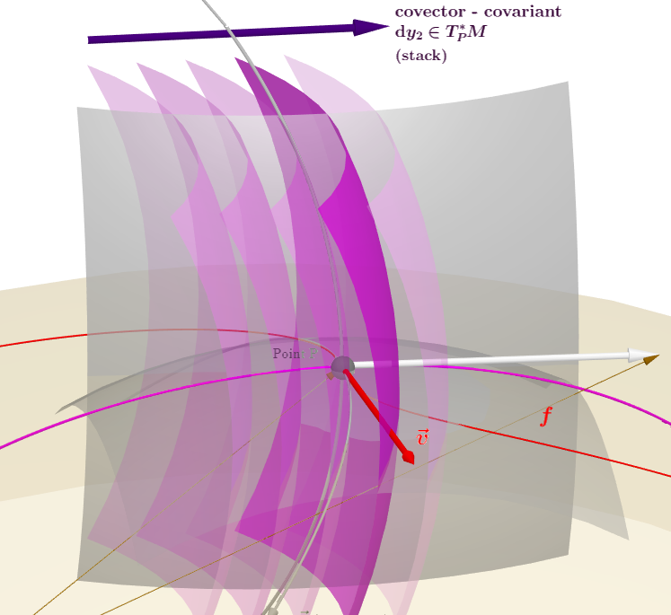

I think this comes to life when we consider how the parametrization of a curve (or a surface) over which to integrate introduces a function (or functions) nested within a function - the velocity at which we move through the curve (?) as opposed to the arc length of the curve being measured, or a vector field on the manifold being integrated along a line. This nested function controls the position vector. So, for example, in [this presentation](https://youtu.be/dhZgGIYzPUU?t=1m17s) the following example is given:

> Evaluate the integral $\displaystyle \int_C y\mathrm dx + z^2 \mathrm dy+x \mathrm dz$ along the curve
> $$\mathrm{\vec R}(t)= \langle
> 2t,t^2,\sqrt{t}\rangle$$
> on the interval $0\leq t \leq4:$

The parametrization is $x(t)= 2t$ with differential $\mathrm dx =2\, \mathrm dt;$ $y(t) = t^2$ with $\mathrm dy=2t\mathrm dt;$ and $z(t)=\sqrt t$ with $\mathrm dz = 1/2 t^{-1/2}\mathrm dt.$

So we can consider this problem as integrating field force over a line:

$$\int_C \mathbf F \cdot \mathrm d\mathbf
R$$
with

$$\begin{align}\mathbf F &=\langle
y,z^2,x\rangle\\[2ex]
&=\langle y(t),(z(t))^2, x(t) \rangle\\[2ex]
&=\Big\langle t^2,\left(t^{1/2}\right)^2, 2t \Big\rangle\\[2ex]
&=\Big\langle t^2,t, 2t \Big\rangle
\end{align}$$
$$\begin{align}
\mathbf R &=\langle x(t),y(t),z(t) \rangle\\
&=\langle 2t,t^2,\sqrt t \rangle
\end{align}$$

and
$$\mathrm d\mathbf R =\langle
x'(t),y'(t),z'(t) \rangle\mathrm dt$$

so that

$$\small\begin{align}
\int_C \mathbf F \cdot \mathrm d\mathbf R&=\int_a^b \mathbf F(
\mathrm {\vec R}(t)) \cdot \mathrm d\mathbf R\\[2ex]
&=\int_a^b \langle P,Q,R \rangle \cdot \langle x'(t),
y'(t),z'(t) \rangle \mathrm dt \\[2ex]
&=\int_0^4 \langle y,z^2,x\rangle \cdot \langle
x'(t),y'(t),z'(t) \rangle\mathrm dt\\[2ex]
&=\int_0^4 \left
(P\frac{dx}{dt}+Q\frac{dy}{dt}+R\frac{dz}{dt}\right){dt}\\[2ex]
&=\int_0^4 \langle t^2,t,2t\rangle \cdot \langle
2,2t,\frac{1}{2}t^{-1/2} \rangle\mathrm dt\\[2ex]
&=\int_0^4 2t^2 \mathrm dt\,+\,2t^2\mathrm dt \,+\, t^{1/2}\mathrm
dt\\[2ex]
&=\int_0^4 \left ( 2t^2 \,+\,2t^2 \,+\, t^{1/2}\right)\mathrm
dt\\[2ex]
&=\frac{4}{3} t^3+\frac{2}{3}t^{3/2}\Big\vert_0^4\\[2ex]
&=272/3
\end{align}$$

In relation to [this question](https://math.stackexchange.com/q/2749672/152225), there is this interesting passage on [this presentation](https://youtu.be/qCE5bmNlpi8?t=14m38s):

> The “new version of the gradient”: The expression corresponding to a vector field
> $$\small\nabla f =\left\langle
> \frac{\partial f}{\partial x},\frac{\partial f}{\partial y},
> \frac{\partial f}{\partial z} \right\rangle$$
> gets replaced with the same partials of the vector field made into a differential form:
> $$\small\mathrm df=\frac{\partial f}{\partial
> x}dx+\frac{\partial f}{\partial y}dy+\frac{\partial f}{\partial
> z}dz$$

> For example,

> $$\mathrm d(x^2+y^2)=2x\,dx + 2y\,
> dy$$
> Here is the gradient (field) representation:

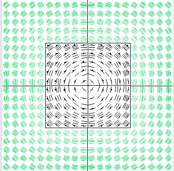

> where the stacks mesh into basically level curves of a function: “Chopping up” the level curves we get the picture of the $\mathrm df,$ which is the “real, honest to god, better version of the gradient.” This graphical representation akin to the level curve cannot be done with the vector field expressed as $\nabla f =\left\langle \frac{\partial f}{\partial x},\frac{\partial f}{\partial y}, \frac{\partial f}{\partial z} \right\rangle$ - basically arrows. Further, if a function is parametrize it is immediate to get

> $$\frac{\mathrm df}{dt} =\frac{\partial
> f}{\partial x}\frac{dx}{dt}+\frac{\partial f}{\partial
> y}\frac{dy}{dt}+\frac{\partial f}{\partial z}\frac{dz}{dt}$$

This is beautifully explaine on [this answer in SE.Math](https://math.stackexchange.com/a/2749923/152225):

**First, some linear algebra.** Take any real $n$-dimensional vector space $V$ and pick a(n ordered) basis $(e_i)$. Then you may pair all vectors in $v$ with $n$-tuples of real numbers so that $v^1 e_1 + \cdots + v^n e_n \leftrightarrow (v^1, \cdots, v^n)$. For vectors, the convention is adopted that these $n$-tuples be written in a vertical fashion – i.e. a second isomorphism is established between $\mathbb R^n$ and the space of column vectors ($n\times 1$ matrices).

Now define the *dual* of $V$ as the vector space of *linear functionals* on $V$, i.e., linear maps $\varphi : V \to \mathbb R$. Our choice of basis $(e_i)$ on $V$ induces a natural choice of basis on $V^*$, the *dual basis* $(\varepsilon^j)$ such that $\varepsilon^j(e_i) = \delta^j_i$ (the Kronecker delta: it corresponds to the value $1$ when $i=j$, $0$ otherwise). This, way, we may also pair every linear functional $\varphi \in V^*$ with an $n$-tuple of real numbers $(\varphi_1,\dots, \varphi_n)$, and the convention now is that they are written in a *horizontal fashion*, i.e. as $1 \times n$ matrices.

Why the row-column vector convention? Because now the action of $\varphi \in V^*$ on $v \in V$ can be written
$$\langle \varphi, v \rangle := \varphi(v) =
\begin{pmatrix} \varphi_1 & \cdots & \varphi_n\end{pmatrix}
\begin{pmatrix} v^1 \\ \vdots \\ v^n \end{pmatrix} = \varphi_1 v^1 +
\cdots \varphi_n v^n$$
so that applying a linear functional to a vector is the same as matrix-multiplying the row vector on the left to the column vector and obtaining a scalar, as you would expect. (The map $\langle\cdot,\cdot\rangle : V^* \times V \to \mathbb R$ is called *duality product* and it is very close to the notion of dot product.) It is worthy of notice that sometimes linear functionals are called *$1$-covariant tensors* or *$(0,1)$-tensors over $V$* or *covectors* and vectors in $V$ are called *$1$-contravariant tensors* or *$(1,0)$-tensors over $V$*.

**Back to geometry/analysis.** Call $\Omega$ an open subset of $n$-dimensional Euclidean space [my words here: just replace omega for $\mathcal M$ - manifold]. Remember that the “partial derivative in the $k$-th direction evaluated at a point $p=(p^1, \dots, p^n) \in \Omega$” operation, $\frac{\partial}{\partial x^k}\Big|_{p=(p^1,\dots,p^n)}$, is linear, that is, if $a,b \in \mathbb R$ and $f,g : \Omega \to \mathbb R$ are smooth functions,
$$\begin{split}
\frac{\partial}{\partial x^k}\Big|_{p} (af + bg) &= \frac{\partial
(af + bg)}{\partial x^k}(p) \\
&=a \frac{\partial f}{\partial x^k}(p) + b \frac{\partial
g}{\partial x^k}(p) \\
&= a \frac{\partial}{\partial x^k}\Big|_{p} f + b
\frac{\partial}{\partial x^k}\Big|_{p} g
\end{split}$$
so it makes sense to consider the vector space of derivations at $p$, that is, the vector space $T_p\Omega$ (also called “tangent space at $p$”) of all linear combinations of partial differential operators
$$\sum_{k=1}^n a^k \frac{\partial}{\partial
x^k}\Big|_{p} = a^1 \frac{\partial}{\partial x^1}\Big|_{p} + \cdots +
a^n\frac{\partial}{\partial x^n}\Big|_{p}$$
It is obvious that $\left(\frac{\partial}{\partial x^k}\Big|_{p}\right)$ constitutes an ordered basis of $T_p\Omega$, which is then $n$-dimensional. Of course, you may apply the column-vector convention and identify the above linear combination with the vertical list $\begin{pmatrix} a^1 \\ \vdots \\ a^n \end{pmatrix}$.

What is then its dual space? It’s the “cotangent space at $p$”, the space $T^*_p\Omega$ of all covectors on $T_p\Omega$. The natural choice of basis on $T^*_p\Omega$ is the dual basis of covectors that yield the Kronecker delta when applied to the pure partial differential operators at $p$. These are the maps
$$\mathrm{d}x^m|_p : T_p\Omega \to \mathbb R \qquad
\text{s.t.} \qquad \mathrm{d} x^m|_p \left(\frac{\partial}{\partial
x^k}\Big|_{p}\right) = \delta^m_k$$
so that any covector $\alpha|_p \in T_p^*\Omega$ can be written as
$$\alpha|_p = \alpha_1 \mathrm{d}x^1|_p +
\cdots + \alpha_n \mathrm{d}x^n|_p.$$

**The directional derivative.** Now you can imagine how this plays out. Let $p \in \Omega$, $v|_p \in T_p\Omega$ and let $f$ be a smooth function over $\Omega$. Then the *directional derivative of $f$ at $p$ in the direction $v|_p$* is just the scalar
$$\begin{split}
\langle \mathrm d f|_p, v|_p \rangle = \mathrm{d}f|_p (v|_p) &=
\begin{pmatrix} \dfrac{\partial f}{\partial x^1}(p) & \cdots &
\dfrac{\partial f}{\partial x^n}(p) \end{pmatrix} \begin{pmatrix} v^1|_p
\\ \vdots \\ v^n|_p \end{pmatrix} = \nabla f(p) \cdot \begin{pmatrix}
v^1|_p \\ \vdots \\ v^n|_p \end{pmatrix} \\ &= v^1|_p
\dfrac{\partial f}{\partial x^1}(p) + \cdots + v^n|_p \dfrac{\partial
f}{\partial x^n}(p)
\end{split}$$
and we are done.

**Addendum.** So far we’ve been working in the tangent space at a single point $p \in \Omega$. But nothing stops us from defining maps that assign, to each point $p \in \Omega$, a vector or a covector. These are called *fields* (although these should be, more sophisticatedly, sections of the tangent or cotangent bundle of $\Omega$). Covector fields are also called *$1$-forms*; for example, $\mathrm{d}f$ is a one form (to each $p$ we assign $\mathrm{d} f|_p$). One may extend the operation of applying a covector to a vector to fields: if $v$ is the vector field such that to each $p$ is associated a vector $v|_p \in T_p\Omega$, and $\alpha$ is a covector field defined similarly, then $\langle\alpha,v\rangle$ is the *scalar field* (i.e., real function) that associates to each $p$ the real number $\langle \alpha|_p,v|_p\rangle = \alpha|_p(v|_p)$. If $\alpha = \mathrm d f$, you get an extension of the definition of directional derivative we gave above: just picture a field of vectors distributed over $\Omega$ and a function $f$ with its gradient, and imagine dotting the gradient at a point with the specific vector assigned at that point, and doing so for all points in $\Omega$. In some way, this gives an idea of “how well” the gradient field conforms to the given vector field.

This is explained on the [covariance and contravariance of vectors entry in Wikipedia](https://en.wikipedia.org/wiki/Covariance_and_contravariance_of_vectors).

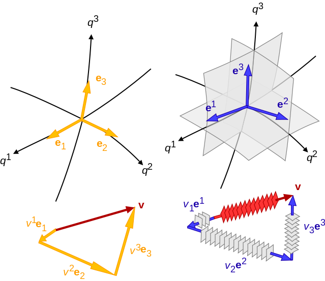

The relation between covariant and contravariant basis is the relation between the tangent vector space and the dual.

[Home Page](http://rinterested.github.io/statistics/index.html)

**NOTE: These are tentative notes on different topics for personal use - expect mistakes and misunderstandings.**